# Graphs and Tables of averaged model outputs (deltas < 2 and 6)

Published

August 9, 2024

# Overview

This file contains information on model outputs for our three key responses, using model-averaging (full model method) on models with delta AICc < 2 and < 6 from the top model. delta < 4 will be discussed in the main paper, and this file provides information for supplementary materials.

## Some notes on coefficients and graphics

Standardized coefficients, as in the coefficient plots and the left columns of the coefficient tables, are interpreted on a scale of standard deviations: one standard deviation in [predictor] is expected to be associated with a [coefficient]-standard deviation change in [response].

In the tables, coefficients have also been back-transformed to the units of the predictors. We must keep in mind that the predictor units are generally not on the scales of variable measurements (nutrient and turbidity trends are “trend in the log-transformed [variable]”, and nutrient and turbidity medians have also been log-transformed. precipitation trend is “trend in square-root of precipitation”).

# Coefficient summaries

## Chl a

**Global model:**

```
chla_trend ~ tpld_PC1 + spcond_median + turb_median.log + temp_trend +
    spcond_trend + turb_trend + chla_median.log + nh4_median.log +
    no23_median.log + po4_median.log + nh4f_trend + no23f_trend +
    po4f_trend + precp_median + precp_trend
```

That formula doesn’t show it, but `Reserve` was included as a random effect.

**# Candidate models:** 32,768

**# models in top set (delta < 2):** 49  
**# models in top set (delta < 6):** 2037

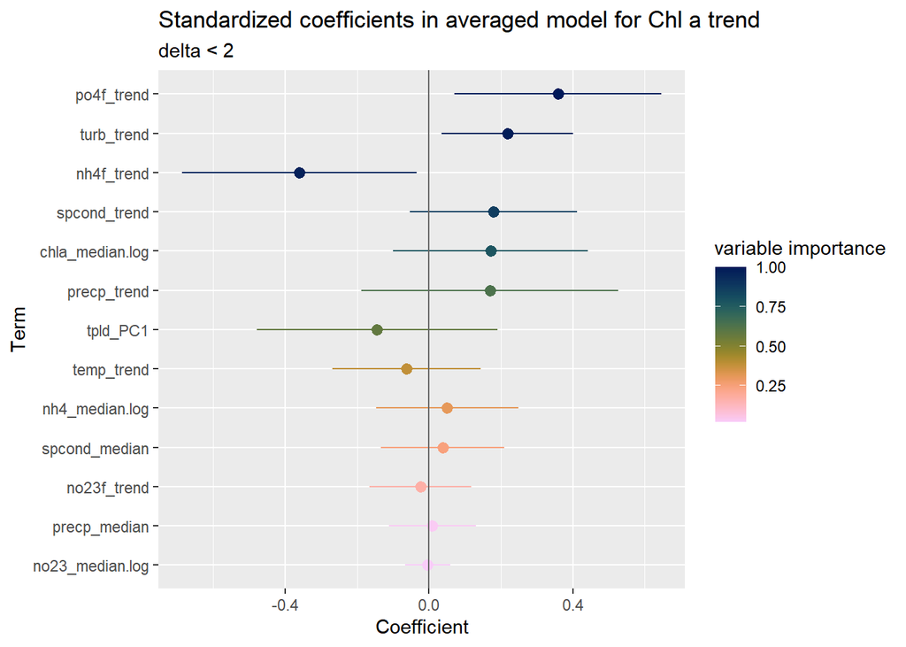

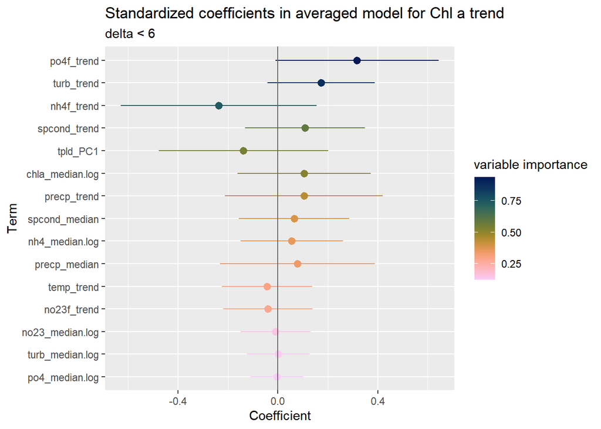

We have the same major 3 predictors for chl trend as we did with delta < 4: phosphate trend (positive association), turbidity trend (positive association), and ammonia trend (negative association). Spcond trend, median chl a, and precip trend are of higher importance with the delta < 2 model. Using delta < 6 seems to shrink coefficients, sometimes fairly substantially.

Coefficients for Chl a trend model

Model averaging with delta AICc < 2

| Predictor | Standardized Estimate | Standardized SE | Predictor Units Estimate | Predictor Units SE | Importance Sum of Weights | Importance # models |
| --- | --- | --- | --- | --- | --- | --- |
| po4f_trend | 0.359 | 0.147 | 0.214 | 0.088 | 1.00 | 49 |
| turb_trend | 0.218 | 0.093 | 0.015 | 0.007 | 0.98 | 48 |
| nh4f_trend | -0.360 | 0.166 | -0.208 | 0.096 | 0.97 | 47 |
| spcond_trend | 0.180 | 0.119 | 0.029 | 0.019 | 0.87 | 41 |
| chla_median.log | 0.171 | 0.139 | 0.006 | 0.005 | 0.78 | 36 |
| precp_trend | 0.169 | 0.182 | 0.093 | 0.100 | 0.64 | 30 |
| tpld_PC1 | -0.144 | 0.171 | -0.003 | 0.003 | 0.58 | 29 |
| temp_trend | -0.062 | 0.105 | -0.090 | 0.151 | 0.38 | 19 |
| nh4_median.log | 0.051 | 0.100 | 0.002 | 0.004 | 0.31 | 16 |
| spcond_median | 0.038 | 0.088 | 0.000 | 0.000 | 0.25 | 12 |
| no23f_trend | -0.024 | 0.072 | -0.012 | 0.038 | 0.17 | 10 |
| precp_median | 0.010 | 0.062 | 0.000 | 0.000 | 0.03 | 2 |
| no23_median.log | -0.004 | 0.032 | 0.000 | 0.001 | 0.02 | 1 |

Coefficients for Chl a trend model

Model averaging with delta AICc < 6

| Predictor | Standardized Estimate | Standardized SE | Predictor Units Estimate | Predictor Units SE | Importance Sum of Weights | Importance # models |
| --- | --- | --- | --- | --- | --- | --- |
| po4f_trend | 0.317 | 0.167 | 0.190 | 0.100 | 0.94 | 1852 |
| turb_trend | 0.173 | 0.110 | 0.012 | 0.008 | 0.87 | 1693 |
| nh4f_trend | -0.237 | 0.200 | -0.137 | 0.116 | 0.74 | 1351 |
| spcond_trend | 0.109 | 0.122 | 0.018 | 0.020 | 0.59 | 1067 |
| tpld_PC1 | -0.138 | 0.173 | -0.002 | 0.003 | 0.54 | 1059 |
| chla_median.log | 0.106 | 0.136 | 0.004 | 0.005 | 0.52 | 952 |
| precp_trend | 0.105 | 0.161 | 0.058 | 0.089 | 0.44 | 829 |
| spcond_median | 0.065 | 0.113 | 0.000 | 0.000 | 0.39 | 854 |
| nh4_median.log | 0.056 | 0.104 | 0.002 | 0.004 | 0.36 | 770 |
| precp_median | 0.078 | 0.158 | 0.000 | 0.000 | 0.34 | 823 |
| temp_trend | -0.044 | 0.092 | -0.063 | 0.133 | 0.30 | 578 |
| no23f_trend | -0.040 | 0.092 | -0.021 | 0.049 | 0.29 | 644 |
| no23_median.log | -0.009 | 0.071 | 0.000 | 0.001 | 0.16 | 395 |
| turb_median.log | 0.001 | 0.064 | 0.000 | 0.002 | 0.13 | 346 |
| po4_median.log | -0.004 | 0.054 | 0.000 | 0.001 | 0.12 | 332 |

## DO mg/L

**Global model:**

```
domgl_trend ~ tpld_PC1 + spcond_median + turb_median.log + temp_trend +
    spcond_trend + turb_trend + chla_median.log + nh4_median.log +
    no23_median.log + po4_median.log + chla_trend + nh4f_trend +
    no23f_trend + po4f_trend + precp_median + precp_trend
```

**# Candidate models:** 65,536

**# models in top set (delta < 2):** 24  
**# models in top set (delta < 6):** 817

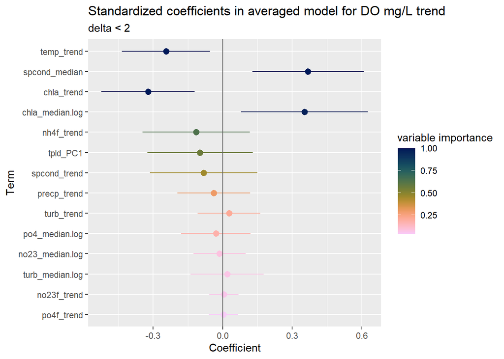

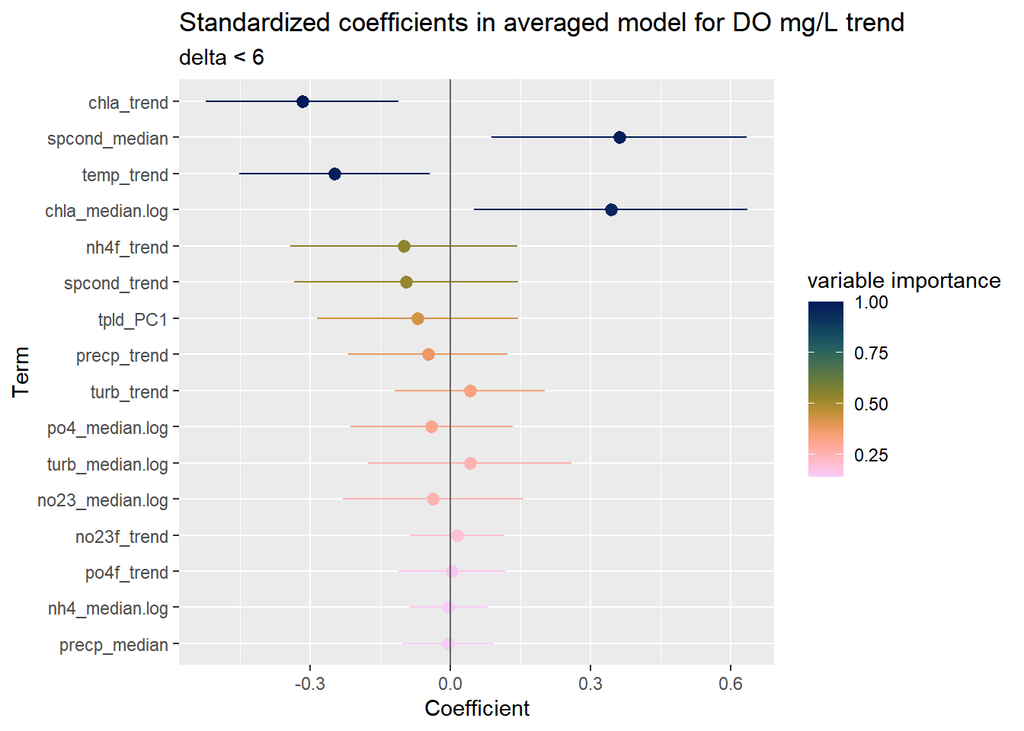

The top 4 predictors stay the same, with similar coefficients, but importance changes slightly. Outputs are more similar for DO mg/L delta 2 vs. 6 than they were for the chl model using different deltas.

Coefficients for DO mg/L trend model

Model averaging with delta AICc < 2

| Predictor | Standardized Estimate | Standardized SE | Predictor Units Estimate | Predictor Units SE | Importance Sum of Weights | Importance # models |
| --- | --- | --- | --- | --- | --- | --- |
| chla_trend | -0.322 | 0.103 | -0.315 | 0.101 | 1.00 | 24 |
| spcond_median | 0.368 | 0.123 | 0.001 | 0.000 | 1.00 | 24 |
| temp_trend | -0.245 | 0.097 | -0.346 | 0.137 | 1.00 | 24 |
| chla_median.log | 0.353 | 0.140 | 0.012 | 0.005 | 0.97 | 23 |
| nh4f_trend | -0.114 | 0.118 | -0.065 | 0.067 | 0.64 | 14 |
| tpld_PC1 | -0.098 | 0.116 | -0.002 | 0.002 | 0.56 | 13 |
| spcond_trend | -0.082 | 0.118 | -0.013 | 0.019 | 0.45 | 12 |
| precp_trend | -0.039 | 0.080 | -0.021 | 0.043 | 0.29 | 8 |
| turb_trend | 0.027 | 0.069 | 0.002 | 0.005 | 0.21 | 5 |
| po4_median.log | -0.029 | 0.076 | -0.001 | 0.002 | 0.17 | 5 |
| no23_median.log | -0.013 | 0.057 | 0.000 | 0.001 | 0.08 | 2 |
| turb_median.log | 0.019 | 0.080 | 0.001 | 0.003 | 0.07 | 2 |
| no23f_trend | 0.005 | 0.032 | 0.003 | 0.017 | 0.06 | 2 |
| po4f_trend | 0.004 | 0.032 | 0.002 | 0.019 | 0.04 | 1 |

Coefficients for DO mg/L trend model

Model averaging with delta AICc < 6

| Predictor | Standardized Estimate | Standardized SE | Predictor Units Estimate | Predictor Units SE | Importance Sum of Weights | Importance # models |
| --- | --- | --- | --- | --- | --- | --- |
| chla_trend | -0.317 | 0.105 | -0.311 | 0.103 | 1.00 | 817 |
| spcond_median | 0.362 | 0.139 | 0.001 | 0.000 | 0.99 | 800 |
| temp_trend | -0.248 | 0.104 | -0.351 | 0.148 | 0.98 | 797 |
| chla_median.log | 0.343 | 0.149 | 0.012 | 0.005 | 0.96 | 772 |
| nh4f_trend | -0.100 | 0.124 | -0.057 | 0.070 | 0.55 | 419 |
| spcond_trend | -0.095 | 0.122 | -0.015 | 0.019 | 0.53 | 457 |
| tpld_PC1 | -0.070 | 0.110 | -0.001 | 0.002 | 0.43 | 327 |
| precp_trend | -0.048 | 0.087 | -0.026 | 0.047 | 0.38 | 339 |
| turb_trend | 0.042 | 0.082 | 0.003 | 0.006 | 0.34 | 300 |
| po4_median.log | -0.041 | 0.089 | -0.001 | 0.002 | 0.31 | 292 |
| turb_median.log | 0.042 | 0.111 | 0.001 | 0.004 | 0.26 | 256 |
| no23_median.log | -0.038 | 0.099 | -0.001 | 0.002 | 0.25 | 242 |
| no23f_trend | 0.014 | 0.051 | 0.007 | 0.027 | 0.19 | 192 |
| po4f_trend | 0.003 | 0.058 | 0.002 | 0.034 | 0.16 | 173 |
| precp_median | -0.005 | 0.050 | 0.000 | 0.000 | 0.14 | 153 |
| nh4_median.log | -0.005 | 0.043 | 0.000 | 0.002 | 0.14 | 156 |

## Proportion of time DO < 2 mg/L

**Global model:**

```
doLT2_trend ~ tpld_PC1 + spcond_median + turb_median.log + temp_trend +
    spcond_trend + turb_trend + chla_median.log + nh4_median.log +
    no23_median.log + po4_median.log + chla_trend + nh4f_trend +
    no23f_trend + po4f_trend + precp_median + precp_trend
```

**# Candidate models:** 65,536

**# models in top set (delta < 2):** 40  
**# models in top set (delta < 6):** 1468

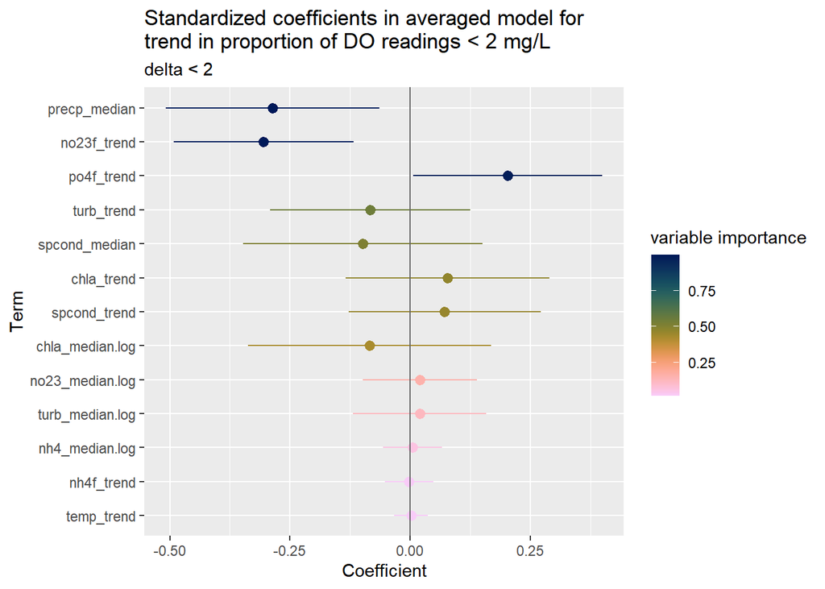

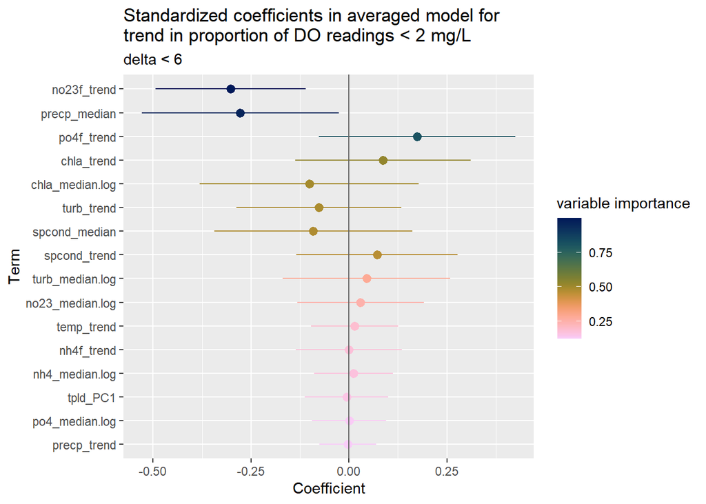

The top three predictors stay the same, as do the moderate ones, though importance shifts around a bit.

Coefficients for DO < 2 trend model

Model averaging with delta AICc < 2

| Predictor | Standardized Estimate | Standardized SE | Predictor Units Estimate | Predictor Units SE | Importance Sum of Weights | Importance # models |
| --- | --- | --- | --- | --- | --- | --- |
| no23f_trend | -0.305 | 0.095 | -0.118 | 0.037 | 1.00 | 40 |
| precp_median | -0.286 | 0.113 | 0.000 | 0.000 | 1.00 | 40 |
| po4f_trend | 0.203 | 0.100 | 0.088 | 0.044 | 0.98 | 39 |
| turb_trend | -0.084 | 0.106 | -0.004 | 0.005 | 0.55 | 23 |
| spcond_median | -0.098 | 0.127 | 0.000 | 0.000 | 0.51 | 19 |
| chla_trend | 0.077 | 0.108 | 0.056 | 0.079 | 0.47 | 19 |
| spcond_trend | 0.071 | 0.102 | 0.008 | 0.012 | 0.46 | 18 |
| chla_median.log | -0.084 | 0.129 | -0.002 | 0.003 | 0.43 | 18 |
| no23_median.log | 0.020 | 0.061 | 0.000 | 0.001 | 0.16 | 8 |
| turb_median.log | 0.020 | 0.071 | 0.000 | 0.002 | 0.12 | 6 |
| nh4_median.log | 0.005 | 0.031 | 0.000 | 0.001 | 0.06 | 3 |
| temp_trend | 0.002 | 0.018 | 0.002 | 0.019 | 0.02 | 1 |
| nh4f_trend | -0.002 | 0.026 | -0.001 | 0.011 | 0.02 | 1 |

Coefficients for DO < 2 trend model

Model averaging with delta AICc < 6

| Predictor | Standardized Estimate | Standardized SE | Predictor Units Estimate | Predictor Units SE | Importance Sum of Weights | Importance # models |
| --- | --- | --- | --- | --- | --- | --- |
| no23f_trend | -0.302 | 0.098 | -0.117 | 0.038 | 1.00 | 1468 |
| precp_median | -0.277 | 0.128 | 0.000 | 0.000 | 0.96 | 1397 |
| po4f_trend | 0.174 | 0.128 | 0.076 | 0.056 | 0.81 | 1119 |
| chla_trend | 0.087 | 0.114 | 0.064 | 0.083 | 0.53 | 784 |
| turb_trend | -0.076 | 0.107 | -0.004 | 0.005 | 0.49 | 718 |
| chla_median.log | -0.101 | 0.143 | -0.003 | 0.004 | 0.49 | 756 |
| spcond_median | -0.091 | 0.129 | 0.000 | 0.000 | 0.48 | 693 |
| spcond_trend | 0.072 | 0.105 | 0.009 | 0.012 | 0.46 | 669 |
| turb_median.log | 0.045 | 0.109 | 0.001 | 0.003 | 0.29 | 488 |
| no23_median.log | 0.030 | 0.082 | 0.000 | 0.001 | 0.25 | 417 |
| temp_trend | 0.014 | 0.057 | 0.015 | 0.060 | 0.19 | 353 |
| nh4f_trend | 0.000 | 0.069 | 0.000 | 0.029 | 0.18 | 335 |
| nh4_median.log | 0.012 | 0.052 | 0.000 | 0.001 | 0.17 | 298 |
| tpld_PC1 | -0.006 | 0.054 | 0.000 | 0.001 | 0.16 | 291 |
| po4_median.log | 0.001 | 0.048 | 0.000 | 0.001 | 0.13 | 249 |
| precp_trend | -0.004 | 0.037 | -0.001 | 0.015 | 0.12 | 235 |